|  | Project Home | EDA Cleanse | EDA Analysis | Feature Engineering | ML Models - Logistical Regression | ML Models - Decision Tree | ML Models - Random Forest | Model Demonstration |
| --- | --- | --- | --- | --- | --- | --- | --- | --- |

# Salifort Motors - ML Modelling - Decision Tree

### Document Information

| Document Title | Salifort Motors - ML Modelling - Decision Tree |
| --- | --- |
| Author | Rod Slater |
| Version | 1.0 |
| Created | 01-11-2023 |
| Modified | 16-11-2023 |

### Client Details

| Client Name | Salifort Motors |
| --- | --- |
| Client Contact | Mr HR Team |
| Client Email | hr@salifortmotors.it |
| Client Project | HR Team Data Driven Solutions from Machine Learning Models |

### Document Overview

ML Modelling using Decision Tree for HR Data provided by Salifort Motors. This notebook details the Decision Tree Modelling process and Performance comparisons

- Salifort Motors - ML Modelling - Decision Tree
  - Document Information
  - Client Details
  - Document Overview
- Decision Tree Model
  - Notes
  - Initialise Notebook
    - Import Packages
    - Set Pandas Options
    - Initialise Notebook Options
    - Define Functions
      - beepr() - make a beep when cell complete (typically fit ops)
      - display_results() - Function to retrieve scores from Results.csv and display them
      - predict_test_scores() - Function to get scores from Prediction models
      - format_GS_results() - Function to get scores from Gridsearch
      - make_lr_results(model_name, model_object, X_var, y_var, y_pred_var)
      - Classification Report
      - Read / Write Pickle Function
- Construct Model - DecisionTree - All Features
  - Import data - DT1
    - Code flags:
  - Prepare data for modelling - DT1
  - Isolate Outcome and Feature Variables - DT1
  - Test Train split data - DT1
  - Begin Modelling `model_dt1` - Train data
    - Instantiate Model - Decision Tree - GridSearch - `model_dt1` - Train data
    - Fit Data
    - Get & Display GridSearch best_estimator results - Decision Tree - Train Data
      - Format and Save Model Scores - `model_dt1` - Train data
      - Display Results - `model_dt1` - Train data
    - Make Predictions - Decision Tree best_model_ - `model_dt1` - Test data
      - Classification Report - `model_dt1` - Test data
      - Prepare and Save Results - Decision Tree - Predict - `model_dt1` - Test data
      - Display Results - Test - `model_dt1` - Test data
    - Make Predictions - Decision Tree best_estimator_ - `model_dt1` - Train data
      - Classification Report - `model_dt1` - Train data
      - Prepare and Save Results - Decision Tree - Predict - `model_dt1` - Train data
      - Display Results
      - Decision Tree Plot - Visualise splits - `model_dt1`
      - Confusion Matrix Plots
      - Feature Importance
- END
- Construct Model - Decision Tree - No Departments
  - Import data - `DT2`
  - Prepare data for modelling - `model_dt2`
  - Isolate Outcome and Feature Variables - `model_dt2`
  - Test Train split data - `model_dt2`
  - Begin Modelling `model_dt2` - Train data
    - Instantiate Model - Decision Tree - GridSearch - `model_dt2` - Train data
    - Fit Data
    - Get & Display GridSearch best_estimator results - `model_dt2` - Train
      - Format and Save Model Scores - `model_dt2` - Train data
      - Display Results - `model_dt2` - Train data
    - Make Predictions - Decision Tree best_model_ - `model_dt2` - Test data
      - Classification Report - `model_dt2` - Test data
      - Prepare and Save Results - Decision Tree - Predict - `model_dt2` - Test data
      - Display Results - Test - `model_dt2` - Test data
    - Make Predictions - Decision Tree best_estimator_ - `model_dt2` - Train data
      - Classification Report - `model_dt2` - Train data
      - Prepare and Save Results - Decision Tree - Predict - `model_dt2` - Train data
      - Display Results
      - Decision Tree Plot - Visualise splits - `model_dt2`
      - Confusion Matrix Plots
      - Feature Importance
- END
- Review Results
  - Dataset comparison - Decision Tree
  - Model performance
- Feature Importance
  - Conclusion, model comparison - Decision Tree.

# Decision Tree Model

## Notes

This runs very quickly, no real need to pickle the model.

## Initialise Notebook

### Import Packages

```python
# Import packages

# Data manipulation
import numpy as np
import pandas as pd

# Data visualization
import matplotlib.pyplot as plt
import seaborn as sns

# Data modelling Imports
from xgboost import XGBClassifier, XGBRegressor, plot_importance

from sklearn.linear_model import LogisticRegression
from sklearn.tree import DecisionTreeClassifier
from sklearn.ensemble import RandomForestClassifier

# For metrics and helpful functions
from sklearn.model_selection import GridSearchCV, train_test_split
from sklearn.metrics import accuracy_score, precision_score, recall_score, precision_recall_fscore_support, \
f1_score, confusion_matrix, ConfusionMatrixDisplay, classification_report
from sklearn.model_selection import learning_curve
from sklearn import metrics
from sklearn.metrics import roc_auc_score, roc_curve
from sklearn.tree import plot_tree
from sklearn.preprocessing import StandardScaler

import statsmodels.api as sm

from datetime import datetime as dt

# For saving models
import pickle
```

### Set Pandas Options

```python
# set Pandas Display Options
pd.options.display.float_format = '{:.2f}'.format
pd.set_option('display.precision', 2)
pd.set_option('display.max_columns', None)
pd.set_option('display.width', 120)
```

### Initialise Notebook Options

```python
load_path = "/home/hass/Documents/Learning/Salifort-Motors-Capstone-Project/00-data_cleaned/"
save_path = "/home/hass/Documents/Learning/Salifort-Motors-Capstone-Project/04-pickle-ML-models/"
```

### Define Functions

#### beepr() - make a beep when cell complete (typically fit ops)

```python
import chime
import time

def beepr():
    for x in range(2):
        for i in range(3):
            chime.success()
            time.sleep(0.25)
        time.sleep(.5)

#beepr()
```

#### display_results() - Function to retrieve scores from Results.csv and display them

```python
def display_results():
    '''
    Load Results.csv containing store test scores, return the scores for display

    In:
        none

    Out: pandas df of Results,csv containing precision, recall, f1, accuracy, AUC scores and prediction count of the models
    '''
    model_results = pd.read_csv("Results.csv")
    model_results.drop(columns=['Unnamed: 0'], inplace=True)
    model_results = model_results.sort_values(by='AUC', ascending=False)

    return model_results
```

#### predict_test_scores() - Function to get scores from Prediction models

```python
def format_predict_results(model_name:str, model, X_test_data, y_test_data):
    '''
    GridSearch : Generate a table of test scores from best_estimator_.predict

    In:
        model_name (string):  How you want your model to be named in the output table
        model:                A fit GridSearchCV object
        X_test_data:          numpy array of X_test data
        y_test_data:          numpy array of y_test data

    Out: pandas df of precision, recall, f1, accuracy, and AUC scores for your model
    '''

    auc = round(roc_auc_score(y_test_data, model),3)
    accuracy = round(accuracy_score(y_test_data, model),3)
    precision = round(precision_score(y_test_data, model),3)
    recall = round(recall_score(y_test_data, model),3)
    f1 = round(f1_score(y_test_data, model),3)

    table = pd.DataFrame({'Model': [model_name],
                          'Precision': [precision],
                          'Recall': [recall],
                          'F1': [f1],
                          'Accuracy': [accuracy],
                          'AUC': [auc]
                         })

    return table
```

#### format_GS_results() - Function to get scores from Gridsearch

```python
def format_GS_results(model_name:str, model_object, metric:str):
    '''
    Arguments:
        model_name (string): what you want the model to be called in the output table
        model_object: a fit GridSearchCV object from test data
        metric (string): precision, recall, f1, accuracy, or auc

    Returns a pandas df with the F1, recall, precision, accuracy, and auc scores
    for the model with the best mean 'metric' score across all GridSearch validation folds.
    '''

    # Create dictionary that maps input metric to actual metric name in GridSearchCV
    metric_dict = {'auc': 'mean_test_roc_auc',
                   'precision': 'mean_test_precision',
                   'recall': 'mean_test_recall',
                   'f1': 'mean_test_f1',
                   'accuracy': 'mean_test_accuracy'
                  }

    # Get all the results from the CV and put them in a df
    cv_results = pd.DataFrame(model_object.cv_results_)

    # Isolate the row of the df with the max(metric) score
    best_estimator_results = cv_results.iloc[cv_results[metric_dict[metric]].idxmax(), :]

    # Extract Accuracy, precision, recall, and f1 score from that row
    auc = round(best_estimator_results.mean_test_roc_auc,3)
    f1 = round(best_estimator_results.mean_test_f1,3)
    recall = round(best_estimator_results.mean_test_recall,3)
    precision = round(best_estimator_results.mean_test_precision,3)
    accuracy = round(best_estimator_results.mean_test_accuracy,3)

    # Create table of results
    table = pd.DataFrame()
    table = pd.DataFrame({'Model': [model_name],
                          'Precision': [precision],
                          'Recall': [recall],
                          'F1': [f1],
                          'Accuracy': [accuracy],
                          'AUC': [auc]
                        })

    return table
```

#### make_lr_results(model_name, model_object, X_var, y_var, y_pred_var)

```python
# Get results from predict to store in comparison table
def make_lr_results(model_name:str, model_object:str, X_var:str, y_var:str, y_pred_var:str):
    '''
    Accepts as arguments :
        a model name (string) - Used as the heading
        a model object : The ML Model
        X_var, y_var, y_pred_var the variables used in the model

    Returns a pandas df with the F1, recall, precision, and accuracy scores
    for the model with the best mean F1 score across all validation folds.
    '''

    # Get all the results from the CV and put them in a dict
    report = classification_report(y_var, y_pred_var,  output_dict=True)

    # Calculate precision, recall, and F1 score for the "True" class
    predict_precision, predict_recall, predict_f1_score, _ = precision_recall_fscore_support(y_var, y_pred_var, average=None)
    f1_true_class = round(predict_f1_score[1],3)  # Index 1 corresponds to the "True" class
    f1_false_class = round(predict_f1_score[0],3)  # Index 1 corresponds to the "True" class


    # Extract accuracy, precision, recall, and f1 score from that row
    f1 = round(report['weighted avg']['f1-score'],3)
    recall = round(report['weighted avg']['recall'],3)
    precision = round(report['weighted avg']['precision'],3)
    accuracy = round(report['accuracy'],3)
    auc = round(roc_auc_score(y_var, model_object.predict_proba(X_var)[:,1]),3)
    # Create table of results
    table = pd.DataFrame({'Model': model_name,
                          'Precision': precision,
                          'Recall': recall,
                          'F1': f1,
                          'Accuracy': accuracy,
                          'AUC': auc,
                          'Predict Leave': f1_true_class,
                          'Predict Stay' : f1_false_class
                        },
                        index=[0]
                       )

    return table
```

#### Classification Report

```python
def classification_report_summary(name:str, y_var:str, y_pred_var:str):
    '''
    Gather stats from predictions

    In:
        name:str    : Test data name for report header e.g. TEST or TRAIN
        y_var       : y variable
        y_pred_var  : y prediction Variable

    Out: Display of precision, recall, f1, accuracy, and AUC scores of the models, Weighted Average and Prediction f1 score for true/false
    '''
    targetnames = ['Predicted would not leave', 'Predicted would leave']



    print("\nClassification Report : ", name)
    print(classification_report(y_var, y_pred_var, target_names=targetnames))

    print("Recall        : {:.2f}".format(recall_score(y_var, y_pred_var)))
    print("f1_score      : {:.2f}".format(f1_score(y_var, y_pred_var)))
    print("Precision     : {:.2f}".format(precision_score(y_var, y_pred_var)))
    print("Accuracy      : {:.2f}".format(accuracy_score(y_var, y_pred_var)))

    report = classification_report(y_var, y_pred_var,  output_dict=True)

    print()
    print('\u2500' * 35)
    print("Weighted Average")
    print('\u2500' * 35)

    print("Recall        : {:.2f}".format(report['weighted avg']['recall']))
    print("f1 Score      : {:.2f}".format(report['weighted avg']['f1-score']))
    print("Precision     : {:.2f}".format(report['weighted avg']['precision']))
    print("Support       : {:.2f}".format(report['weighted avg']['support']))

      # Calculate precision, recall, and F1 score for the "True" class
    predict_precision, predict_recall, predict_f1_score, _ = precision_recall_fscore_support(y_var, y_pred_var, average=None)
    f1_true_class = predict_f1_score[1]  # Index 1 corresponds to the "True" class
    f1_false_class = predict_f1_score[0]  # Index 0 corresponds to the "False" class

    print()
    print('\u2500' * 35)
    print("Prediction F1 score")
    print('\u2500' * 35)
    print("Predict Leave : {:.2f}".format(f1_true_class))
    print("Predict Stay  : {:.2f}".format(f1_false_class))
```

#### Read / Write Pickle Function

- write_pickle = Write the model
- read_pickle = Read the model

```python
def write_pickle(path, model_object, save_as:str):
    '''
    In:
        path:         path of folder where you want to save the pickle
        model_object: a model you want to pickle
        save_as:      filename for how you want to save the model

    Out: A call to pickle the model in the folder indicated
    '''

    with open(path + save_as + '.pickle', 'wb') as to_write:
        pickle.dump(model_object, to_write)

def read_pickle(path, saved_model_name:str):
    '''
    In:
        path:             path to folder where you want to read from
        saved_model_name: filename of pickled model you want to read in

    Out:
        model: the pickled model
    '''
    with open(path + saved_model_name + '.pickle', 'rb') as to_read:
        model = pickle.load(to_read)

    return model
```

# Construct Model - DecisionTree - All Features

## Import data - `DT1`

Two datasets for model performance comparison, :

- `data_cleaned_NoOl_FE_AllFeat.csv` is the full data set feature engineered with `salary` encoded to ordinal, `avg_mth_hrs` binary encoded to `overwork` and dept encoded with dummies
- `data_cleaned_NoOl_FE_NoDept.csv` is the same data with the dummy encoded dept fields removed.

`Dept` appears to have low correlation across the dataset and I'm curious how much the models are influenced with low correlation features. It turns out that low correlation features have little impact on model performance. which is no surprise really!

#### Code flags:

**rerun** = flag to identify the first run of the model comparisons and write a NEW Results.csv file. 0 = first run and a new file will be created with headers / 1 = Continuation, Results will be appended to the file.

**dataset** = Text indicating which dataset is being used, added to the model description during csv save to Results.csv

**model_prefix** = text indicating which ML model is being used, added to the model description during csv save to Results.csv

```python
# Load cleaned dataset into a dataframe
df1 = pd.read_csv(load_path + "data_cleaned_NoOl_FE_AllFeat.csv", index_col = False) # Feature engineering on salary, avg_mnth_hrs, dept, outliers removed

# model_prefix : Str = prefix for results.csv added to dataset
model_prefix     = 'dt1'

# dataset : Str = dataset name for results.csv
dataset          = 'ALLFeat'

# rerun : int =  Flag to set 1 = append to Results.csv / 0 = Overwrite with new file
rerun            = 1

print("df1 - Feature engineering on salary, avg_mnth_hrs, dept, outliers removed\n")

# Display dataframe columns
print(df1.info())
```

```
df1 - Feature engineering on salary, avg_mnth_hrs, dept, outliers removed

<class 'pandas.core.frame.DataFrame'>
RangeIndex: 11167 entries, 0 to 11166
Data columns (total 18 columns):
 #   Column            Non-Null Count  Dtype
---  ------            --------------  -----
 0   satisfaction      11167 non-null  float64
 1   last_eval         11167 non-null  float64
 2   number_project    11167 non-null  float64
 3   tenure            11167 non-null  float64
 4   left              11167 non-null  float64
 5   promotion         11167 non-null  float64
 6   salary            11167 non-null  int64
 7   dept_accounting   11167 non-null  bool
 8   dept_hr           11167 non-null  bool
 9   dept_it           11167 non-null  bool
 10  dept_management   11167 non-null  bool
 11  dept_marketing    11167 non-null  bool
 12  dept_product_mng  11167 non-null  bool
 13  dept_randd        11167 non-null  bool
 14  dept_sales        11167 non-null  bool
 15  dept_support      11167 non-null  bool
 16  dept_technical    11167 non-null  bool
 17  overworked        11167 non-null  int64
dtypes: bool(10), float64(6), int64(2)
memory usage: 807.1 KB
None
```

## Prepare data for modelling - DT1

```python
model_data = df1.copy()
```

## Isolate Outcome and Feature Variables - DT1

```python
# Isolate the outcome and feature variables

# Isolate the outcome variable 'left' is a binary value where true = employee left employment
Y = model_data['left']

# Select & Isolate the feature variables and drop the outcome variable
X = model_data.copy()
X = X.drop('left', axis = 1)
```

## Test Train split data - DT1

```python
# Prepare training and test data
X_train, X_test, y_train, y_test = train_test_split(X,Y, test_size=0.25, stratify=Y, random_state=0)
print(X_train.shape)
print(y_train.shape)
print(X_test.shape)
print(y_test.shape)
```

```
(8375, 17)
(8375,)
(2792, 17)
(2792,)
```

## Begin Modelling `model_dt1` - Train data

The DecisionTree model is a good starting place.

[output not shown]

### Instantiate Model - Decision Tree - GridSearch - `model_dt1` - Train data

```python
# Instantiate model
dtc = DecisionTreeClassifier(random_state=0)

# Assign a dictionary of hyperparameters to search over
cv_params = {'max_depth':[4, 6, 8, None],
             'min_samples_leaf': [2, 5, 1],
             'min_samples_split': [2, 4, 6]
             }

# Assign a dictionary of scoring metrics to capture
scoring = ('accuracy', 'precision', 'recall', 'f1', 'roc_auc')

# Instantiate GridSearch
model_dt1 = GridSearchCV(dtc, cv_params, scoring=scoring, cv=4, refit='roc_auc')
```

### Fit Data

```python
%%time
print("Started / Last Run =", dt.now().strftime("%Y-%m-%d %H:%M:%S"))
model_dt1.fit(X_train, y_train)
beepr()
```

```
Started / Last Run = 2023-11-20 13:52:52
CPU times: user 4.79 s, sys: 28.7 ms, total: 4.82 s
Wall time: 7.42 s
```

### Get & Display GridSearch best_estimator results - Decision Tree - Train Data

```python
print("Start Time =", dt.now().strftime("%H:%M:%S"))
# Get the parameters of the best-performing model
print(model_prefix+' - '+dataset+' - '+'test\n')
print("Best Parameters : ", model_dt1.best_params_)

# Get the average f1 score of the best-performing model
print("Best Score      : {:.4f}".format(model_dt1.best_score_))

# Get the best estimators of the parameters
print("Best Estimator  : ", model_dt1.best_estimator_)
```

```
Start Time = 13:53:00
dt1 - ALLFeat - test

Best Parameters :  {'max_depth': 4, 'min_samples_leaf': 1, 'min_samples_split': 2}
Best Score      : 0.9737
Best Estimator  :  DecisionTreeClassifier(max_depth=4, random_state=0)
```

#### Format and Save Model Scores - `model_dt1` - Train data

```python
model_dt1_cv_results = format_GS_results(model_prefix+' - '+dataset+' - '+'GS train', model_dt1, 'auc')
model_dt1_cv_results.to_csv("Results.csv", mode='a', index=True, header=False)
```

#### Display Results - `model_dt1` - Train data

```python
pd.options.display.float_format = '{:.3f}'.format
#print(model_dt1_cv_results,"\n")
display_results()
```

|  | Model | Precision | Recall | F1 | Accuracy | AUC | Predict Leave | Predict Stay |
| --- | --- | --- | --- | --- | --- | --- | --- | --- |
| 4 | dt1 - ALLFeat - GS train | 0.951 | 0.914 | 0.932 | 0.977 | 0.974 | NaN | NaN |
| 1 | lr1 - ALLFeat - train | 0.774 | 0.813 | 0.786 | 0.813 | 0.887 | 0.258 | 0.893 |
| 3 | lr2 - NOdept - train | 0.770 | 0.811 | 0.783 | 0.811 | 0.886 | 0.247 | 0.892 |
| 0 | lr1 - ALLFeat - test | 0.776 | 0.811 | 0.788 | 0.811 | 0.878 | 0.277 | 0.891 |
| 2 | lr2 - NOdept - test | 0.767 | 0.806 | 0.781 | 0.806 | 0.878 | 0.248 | 0.889 |

### Make Predictions - Decision Tree best_model_ - `model_dt1` - Test data

```python
# Make predictions on test data

model_dt1_best_model = model_dt1.best_estimator_ # Save the best parameters for later testing
y_pred_test = model_dt1_best_model.predict(X_test)
```

#### Classification Report - `model_dt1` - Test data

```python
# def classification_report_summary(name:str, y_var:str, y_pred_var:str):

classification_report_summary(model_prefix+' - '+dataset+' - '+'test', y_test,y_pred_test)
```

```
Classification Report :  dt1 - ALLFeat - test
                           precision    recall  f1-score   support

Predicted would not leave       0.99      0.99      0.99      2321
    Predicted would leave       0.94      0.93      0.94       471

                 accuracy                           0.98      2792
                macro avg       0.96      0.96      0.96      2792
             weighted avg       0.98      0.98      0.98      2792

Recall        : 0.93
f1_score      : 0.94
Precision     : 0.94
Accuracy      : 0.98

───────────────────────────────────
Weighted Average
───────────────────────────────────
Recall        : 0.98
f1 Score      : 0.98
Precision     : 0.98
Support       : 2792.00

───────────────────────────────────
Prediction F1 score
───────────────────────────────────
Predict Leave : 0.94
Predict Stay  : 0.99
```

#### Prepare and Save Results - Decision Tree - Predict - `model_dt1` - Test data

```python
#make_lr_results(model_name:str, model_object:str, X_var:str, y_var:str, y_pred_var:str)

# format prediction results into a dataframe
dt_pred_test_results = make_lr_results(model_prefix+' - '+dataset+' - '+'test', model_dt1_best_model, X_test, y_test, y_pred_test)

# save the prediction results in Results.csv
dt_pred_test_results.to_csv("Results.csv", mode='a', index=True, header=False)
```

#### Display Results - Test - `model_dt1` - Test data

```python
print(dt_pred_test_results) # Display results of the prediction
display_results() # Display contents of Results.csv
```

```
                  Model  Precision  Recall    F1  Accuracy   AUC  Predict Leave  Predict Stay
0  dt1 - ALLFeat - test      0.978   0.979 0.978     0.979 0.979          0.936         0.987
```

|  | Model | Precision | Recall | F1 | Accuracy | AUC | Predict Leave | Predict Stay |
| --- | --- | --- | --- | --- | --- | --- | --- | --- |
| 5 | dt1 - ALLFeat - test | 0.978 | 0.979 | 0.978 | 0.979 | 0.979 | 0.936 | 0.987 |
| 4 | dt1 - ALLFeat - GS train | 0.951 | 0.914 | 0.932 | 0.977 | 0.974 | NaN | NaN |
| 1 | lr1 - ALLFeat - train | 0.774 | 0.813 | 0.786 | 0.813 | 0.887 | 0.258 | 0.893 |
| 3 | lr2 - NOdept - train | 0.770 | 0.811 | 0.783 | 0.811 | 0.886 | 0.247 | 0.892 |
| 0 | lr1 - ALLFeat - test | 0.776 | 0.811 | 0.788 | 0.811 | 0.878 | 0.277 | 0.891 |
| 2 | lr2 - NOdept - test | 0.767 | 0.806 | 0.781 | 0.806 | 0.878 | 0.248 | 0.889 |

### Make Predictions - Decision Tree best_estimator_ - `model_dt1` - Train data

```python
# Make predictions on train data
print("Started / Last Run =", dt.now().strftime("%Y-%m-%d %H:%M:%S"))

model_dt1_best_model = model_dt1.best_estimator_ # Save the best parameters for later testing
y_pred_train = model_dt1_best_model.predict(X_train)
```

```
Started / Last Run = 2023-11-20 13:53:01
```

#### Classification Report - `model_dt1` - Train data

```python
# def classification_report_summary(name:str, y_var:str, y_pred_var:str):

classification_report_summary(model_prefix+' - '+dataset+' - '+'train', y_train,y_pred_train)
```

```
Classification Report :  dt1 - ALLFeat - train
                           precision    recall  f1-score   support

Predicted would not leave       0.98      0.99      0.99      6964
    Predicted would leave       0.96      0.92      0.94      1411

                 accuracy                           0.98      8375
                macro avg       0.97      0.95      0.96      8375
             weighted avg       0.98      0.98      0.98      8375

Recall        : 0.92
f1_score      : 0.94
Precision     : 0.96
Accuracy      : 0.98

───────────────────────────────────
Weighted Average
───────────────────────────────────
Recall        : 0.98
f1 Score      : 0.98
Precision     : 0.98
Support       : 8375.00

───────────────────────────────────
Prediction F1 score
───────────────────────────────────
Predict Leave : 0.94
Predict Stay  : 0.99
```

#### Prepare and Save Results - Decision Tree - Predict - `model_dt1` - Train data

```python
#make_lr_results(model_name:str, model_object:str, X_var:str, y_var:str, y_pred_var:str)

# format prediction results into a dataframe
dt_pred_test_results = make_lr_results(model_prefix+' - '+dataset+' - '+'train', model_dt1_best_model, X_train, y_train, y_pred_train)

# Save dataframe into results.csv, no header
dt_pred_test_results.to_csv("Results.csv", mode='a', index=True, header=False) # save the prediction results in Results.csv
```

#### Display Results

```python
print(dt_pred_test_results) # Display results of the prediction
pd.options.display.float_format = '{:.3f}'.format
display_results() # Display contents of Results.csv
```

```
                   Model  Precision  Recall    F1  Accuracy   AUC  Predict Leave  Predict Stay
0  dt1 - ALLFeat - train      0.978   0.979 0.978     0.979 0.979          0.935         0.987
```

|  | Model | Precision | Recall | F1 | Accuracy | AUC | Predict Leave | Predict Stay |
| --- | --- | --- | --- | --- | --- | --- | --- | --- |
| 5 | dt1 - ALLFeat - test | 0.978 | 0.979 | 0.978 | 0.979 | 0.979 | 0.936 | 0.987 |
| 6 | dt1 - ALLFeat - train | 0.978 | 0.979 | 0.978 | 0.979 | 0.979 | 0.935 | 0.987 |
| 4 | dt1 - ALLFeat - GS train | 0.951 | 0.914 | 0.932 | 0.977 | 0.974 | NaN | NaN |
| 1 | lr1 - ALLFeat - train | 0.774 | 0.813 | 0.786 | 0.813 | 0.887 | 0.258 | 0.893 |
| 3 | lr2 - NOdept - train | 0.770 | 0.811 | 0.783 | 0.811 | 0.886 | 0.247 | 0.892 |
| 0 | lr1 - ALLFeat - test | 0.776 | 0.811 | 0.788 | 0.811 | 0.878 | 0.277 | 0.891 |
| 2 | lr2 - NOdept - test | 0.767 | 0.806 | 0.781 | 0.806 | 0.878 | 0.248 | 0.889 |

#### Decision Tree Plot - Visualise splits - `model_dt1`

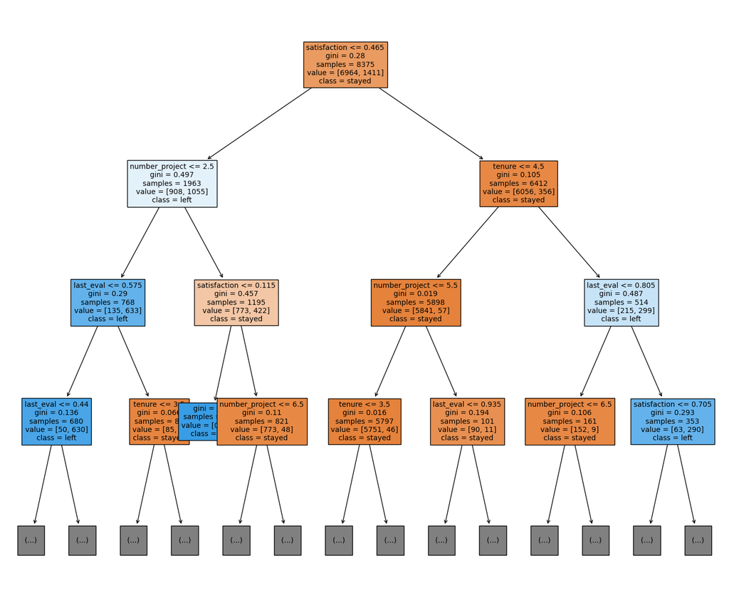

```python
plt.figure(figsize=(18,15))
plot_tree(model_dt1_best_model,max_depth=3, fontsize=10, feature_names=X_test.columns, class_names={0:'stayed',1:'left'}, filled=True);
plt.show()
```

#### Confusion Matrix Plots

```python
# Prepare confusion matrices for dt1 test
cm_test = metrics.confusion_matrix(y_test, y_pred_test)  # Use the optimized model
cm_test_percent = cm_test / cm_test.sum() * 100

# Prepare confusion matrices for dt1 train
cm_train = metrics.confusion_matrix(y_train, y_pred_train)  # Use the optimized model
cm_train_percent = cm_train / cm_train.sum() * 100
```

```
<function matplotlib.pyplot.show(close=None, block=None)>
```

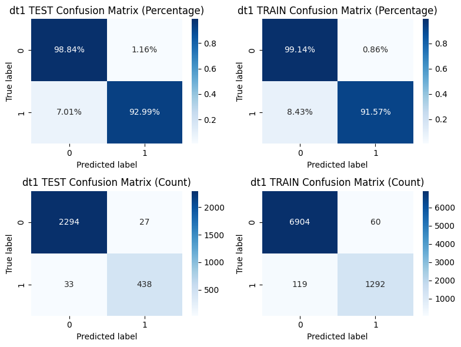

```python
fig, ax = plt.subplots(2, 2, figsize=(8,6))


ax[0,0].set_title("test")

sum_by_true_class = np.sum(cm_test, axis=1)
percentage_matrix = cm_test / sum_by_true_class[:, np.newaxis]

# Create a figure and plot the percentage confusion matrix as a heatmap

sns.heatmap(percentage_matrix, annot=True, fmt=".2%", cmap="Blues", ax = ax[0,0])#, xticklabels=class_labels, yticklabels=class_labels)
ax[0,0].set_title(model_prefix+' TEST Confusion Matrix (Percentage)')
ax[0,0].set_ylabel('True label')
ax[0,0].set_xlabel('Predicted label')

# Create a figure and plot the percentage confusion matrix as a heatmap
sns.heatmap(cm_test, annot=True, fmt=".0f", cmap="Blues", ax = ax[1,0])#, xticklabels=class_labels, yticklabels=class_labels)
ax[1,0].set_title(model_prefix+' TEST Confusion Matrix (Count)')
ax[1,0].set_ylabel('True label')
ax[1,0].set_xlabel('Predicted label')

sum_by_true_class = np.sum(cm_train, axis=1)
percentage_matrix = cm_train / sum_by_true_class[:, np.newaxis]

sns.heatmap(percentage_matrix, annot=True, fmt=".2%", cmap="Blues", ax = ax[0,1])#, xticklabels=class_labels, yticklabels=class_labels)
ax[0,1].set_title(model_prefix+' TRAIN Confusion Matrix (Percentage)')
ax[0,1].set_ylabel('True label')
ax[0,1].set_xlabel('Predicted label')


sns.heatmap(cm_train, annot=True, fmt=".0f", cmap="Blues", ax = ax[1,1])#, xticklabels=class_labels, yticklabels=class_labels)
ax[1,1].set_title(model_prefix+' TRAIN Confusion Matrix (Count)')
ax[1,1].set_ylabel('True label')
ax[1,1].set_xlabel('Predicted label')

plt.tight_layout()
plt.show
```

#### Feature Importance

```python
#tree2_importances = pd.DataFrame(tree2.best_estimator_.feature_importances_, columns=X.columns)
tree_importances = pd.DataFrame(model_dt1.best_estimator_.feature_importances_,
                                 columns=['gini_importance'],
                                 index=X.columns
                                )
tree_importances = tree_importances.sort_values(by='gini_importance', ascending=False)

# Only extract the features with importances > 0
#tree_importances = tree_importances[tree_importances['gini_importance'] != 0]
tree_importances
```

|  | gini_importance |
| --- | --- |
| satisfaction | 0.590 |
| tenure | 0.154 |
| last_eval | 0.148 |
| number_project | 0.109 |
| dept_marketing | 0.000 |
| dept_technical | 0.000 |
| dept_support | 0.000 |
| dept_sales | 0.000 |
| dept_randd | 0.000 |
| dept_product_mng | 0.000 |
| dept_it | 0.000 |
| dept_management | 0.000 |
| dept_hr | 0.000 |
| dept_accounting | 0.000 |
| salary | 0.000 |
| promotion | 0.000 |
| overworked | 0.000 |

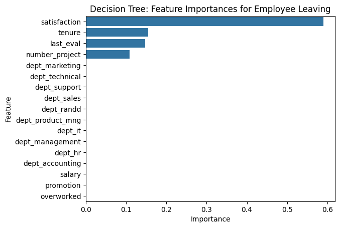

```python
sns.barplot(data=tree_importances, x="gini_importance", y=tree_importances.index, orient='h')
plt.title("Decision Tree: Feature Importances for Employee Leaving", fontsize=12)
plt.ylabel("Feature")
plt.xlabel("Importance")
#plt.gca().invert_yaxis()
plt.show()
```

# Construct Model - Decision Tree - No Departments

## Import data - `DT2`

```python
df2 = pd.read_csv(load_path + "data_cleaned_NoOl_FE_NoDept.csv", index_col = False) # Feature engineering on salary, avg_mnth_hrs, outliers removed, departments removed

model_prefix      = 'dt2'         # prefix for results.csv added to dataset
dataset           = 'NOdept'      # dataset name for results.csv
rerun             = 1             # 1 = mode = 'a' append to the Results.csv file / 0 = no mode, write new file.

print("df2 - Feature engineering on salary, avg_mnth_hrs, dept REMOVED, outliers removed\n")

# Display dataframe columns
print(df2.info())
```

```
df2 - Feature engineering on salary, avg_mnth_hrs, dept REMOVED, outliers removed

<class 'pandas.core.frame.DataFrame'>
RangeIndex: 11167 entries, 0 to 11166
Data columns (total 8 columns):
 #   Column          Non-Null Count  Dtype
---  ------          --------------  -----
 0   satisfaction    11167 non-null  float64
 1   last_eval       11167 non-null  float64
 2   number_project  11167 non-null  float64
 3   overworked      11167 non-null  int64
 4   tenure          11167 non-null  float64
 5   left            11167 non-null  float64
 6   promotion       11167 non-null  float64
 7   salary          11167 non-null  int64
dtypes: float64(6), int64(2)
memory usage: 698.1 KB
None
```

## Prepare data for modelling - `model_dt2`

```python
model_data2 = df2.copy()
```

## Isolate Outcome and Feature Variables - `model_dt2`

```python
# Isolate the outcome and feature variables

# Isolate the outcome variable 'left' is a binary value where true = employee left employment
Y2 = model_data2['left']

# Select & Isolate the feature variables and drop the outcome variable
X2 = model_data2.copy()
X2 = X2.drop('left', axis = 1)
```

## Test Train split data - `model_dt2`

```python
# Prepare training and test data
X_train2, X_test2, y_train2, y_test2 = train_test_split(X2,Y2, test_size=0.25, stratify=Y, random_state=0)
```

## Begin Modelling `model_dt2` - Train data

The DecisionTree model is a good starting place.

[output not shown]

### Instantiate Model - Decision Tree - GridSearch - `model_dt2` - Train data

```python
# Instantiate model
tree2 = DecisionTreeClassifier(random_state=0)

# Assign a dictionary of hyperparameters to search over
cv_params = {'max_depth':[4, 6, 8, None],
             'min_samples_leaf': [2, 5, 1],
             'min_samples_split': [2, 4, 6]
             }

# Assign a dictionary of scoring metrics to capture
scoring = ('accuracy', 'precision', 'recall', 'f1', 'roc_auc')

# Instantiate GridSearch
model_dt2 = GridSearchCV(tree2, cv_params, scoring=scoring, cv=4, refit='roc_auc')
```

### Fit Data

```python
%%time
model_dt2.fit(X_train2, y_train2)
beepr()
```

```
CPU times: user 3.89 s, sys: 8.21 ms, total: 3.9 s
Wall time: 6.42 s
```

### Get & Display GridSearch best_estimator results - `model_dt2` - Train

```python
# Get the parameters of the best-performing model
print(model_prefix+' - '+dataset+' - '+'test\n')
print("Best Parameters : ", model_dt2.best_params_)

# Get the average f1 score of the best-performing model
print("Best Score      : {:.4f}".format(model_dt2.best_score_))

# Get the best estimators of the parameters
print("Best Estimator  : ", model_dt2.best_estimator_)
```

```
dt2 - NOdept - test

Best Parameters :  {'max_depth': 4, 'min_samples_leaf': 1, 'min_samples_split': 2}
Best Score      : 0.9737
Best Estimator  :  DecisionTreeClassifier(max_depth=4, random_state=0)
```

#### Format and Save Model Scores - `model_dt2` - Train data

```python
model_dt2_cv_results = format_GS_results(model_prefix+' - '+dataset+' - '+'GS train', model_dt2, 'auc')
model_dt2_cv_results.to_csv("Results.csv", mode='a', index=True, header=False)
```

#### Display Results - `model_dt2` - Train data

```python
pd.options.display.float_format = '{:.3f}'.format
print(model_dt2_cv_results,"\n")
display_results()
```

```
                     Model  Precision  Recall    F1  Accuracy   AUC
0  dt2 - NOdept - GS train      0.951   0.914 0.932     0.977 0.974
```

|  | Model | Precision | Recall | F1 | Accuracy | AUC | Predict Leave | Predict Stay |
| --- | --- | --- | --- | --- | --- | --- | --- | --- |
| 5 | dt1 - ALLFeat - test | 0.978 | 0.979 | 0.978 | 0.979 | 0.979 | 0.936 | 0.987 |
| 6 | dt1 - ALLFeat - train | 0.978 | 0.979 | 0.978 | 0.979 | 0.979 | 0.935 | 0.987 |
| 4 | dt1 - ALLFeat - GS train | 0.951 | 0.914 | 0.932 | 0.977 | 0.974 | NaN | NaN |
| 7 | dt2 - NOdept - GS train | 0.951 | 0.914 | 0.932 | 0.977 | 0.974 | NaN | NaN |
| 1 | lr1 - ALLFeat - train | 0.774 | 0.813 | 0.786 | 0.813 | 0.887 | 0.258 | 0.893 |
| 3 | lr2 - NOdept - train | 0.770 | 0.811 | 0.783 | 0.811 | 0.886 | 0.247 | 0.892 |
| 0 | lr1 - ALLFeat - test | 0.776 | 0.811 | 0.788 | 0.811 | 0.878 | 0.277 | 0.891 |
| 2 | lr2 - NOdept - test | 0.767 | 0.806 | 0.781 | 0.806 | 0.878 | 0.248 | 0.889 |

### Make Predictions - Decision Tree best_model_ - `model_dt2` - Test data

```python
# Make predictions on test data

model_dt2_best_model = model_dt2.best_estimator_ # Save the best parameters for later testing
y_pred_test2 = model_dt2_best_model.predict(X_test2)
```

#### Classification Report - `model_dt2` - Test data

```python
# def classification_report_summary(name:str, y_var:str, y_pred_var:str):

classification_report_summary(model_prefix+' - '+dataset+' - '+'test', y_test2,y_pred_test2)
```

```
Classification Report :  dt2 - NOdept - test
                           precision    recall  f1-score   support

Predicted would not leave       0.99      0.99      0.99      2321
    Predicted would leave       0.94      0.93      0.94       471

                 accuracy                           0.98      2792
                macro avg       0.96      0.96      0.96      2792
             weighted avg       0.98      0.98      0.98      2792

Recall        : 0.93
f1_score      : 0.94
Precision     : 0.94
Accuracy      : 0.98

───────────────────────────────────
Weighted Average
───────────────────────────────────
Recall        : 0.98
f1 Score      : 0.98
Precision     : 0.98
Support       : 2792.00

───────────────────────────────────
Prediction F1 score
───────────────────────────────────
Predict Leave : 0.94
Predict Stay  : 0.99
```

#### Prepare and Save Results - Decision Tree - Predict - `model_dt2` - Test data

```python
dt_pred_test_results2 = make_lr_results(model_prefix+' - '+dataset+' - '+'test', model_dt2_best_model, X_test2, y_test2, y_pred_test2) # format prediction results into a dataframe
dt_pred_test_results2.to_csv("Results.csv", mode='a', index=True, header=False) # save the prediction results in Results.csv
```

#### Display Results - Test - `model_dt2` - Test data

```python
print(dt_pred_test_results2) # Display results of the prediction
display_results() # Display contents of Results.csv
```

```
                 Model  Precision  Recall    F1  Accuracy   AUC  Predict Leave  Predict Stay
0  dt2 - NOdept - test      0.978   0.979 0.978     0.979 0.979          0.936         0.987
```

|  | Model | Precision | Recall | F1 | Accuracy | AUC | Predict Leave | Predict Stay |
| --- | --- | --- | --- | --- | --- | --- | --- | --- |
| 5 | dt1 - ALLFeat - test | 0.978 | 0.979 | 0.978 | 0.979 | 0.979 | 0.936 | 0.987 |
| 6 | dt1 - ALLFeat - train | 0.978 | 0.979 | 0.978 | 0.979 | 0.979 | 0.935 | 0.987 |
| 8 | dt2 - NOdept - test | 0.978 | 0.979 | 0.978 | 0.979 | 0.979 | 0.936 | 0.987 |
| 4 | dt1 - ALLFeat - GS train | 0.951 | 0.914 | 0.932 | 0.977 | 0.974 | NaN | NaN |
| 7 | dt2 - NOdept - GS train | 0.951 | 0.914 | 0.932 | 0.977 | 0.974 | NaN | NaN |
| 1 | lr1 - ALLFeat - train | 0.774 | 0.813 | 0.786 | 0.813 | 0.887 | 0.258 | 0.893 |
| 3 | lr2 - NOdept - train | 0.770 | 0.811 | 0.783 | 0.811 | 0.886 | 0.247 | 0.892 |
| 0 | lr1 - ALLFeat - test | 0.776 | 0.811 | 0.788 | 0.811 | 0.878 | 0.277 | 0.891 |
| 2 | lr2 - NOdept - test | 0.767 | 0.806 | 0.781 | 0.806 | 0.878 | 0.248 | 0.889 |

### Make Predictions - Decision Tree best_estimator_ - `model_dt2` - Train data

```python
# Make predictions on train data
print("Current Time =", dt.now().strftime("%H:%M:%S"))

dt_best_model2 = model_dt2.best_estimator_ # Save the best parameters for later testing
y_pred_train2 = model_dt2_best_model.predict(X_train2)
```

```
Current Time = 13:53:13
```

#### Classification Report - `model_dt2` - Train data

```python
# def classification_report_summary(name:str, y_var:str, y_pred_var:str):

classification_report_summary(model_prefix+' - '+dataset+' - '+'train', y_train2,y_pred_train2)
```

```
Classification Report :  dt2 - NOdept - train
                           precision    recall  f1-score   support

Predicted would not leave       0.98      0.99      0.99      6964
    Predicted would leave       0.96      0.92      0.94      1411

                 accuracy                           0.98      8375
                macro avg       0.97      0.95      0.96      8375
             weighted avg       0.98      0.98      0.98      8375

Recall        : 0.92
f1_score      : 0.94
Precision     : 0.96
Accuracy      : 0.98

───────────────────────────────────
Weighted Average
───────────────────────────────────
Recall        : 0.98
f1 Score      : 0.98
Precision     : 0.98
Support       : 8375.00

───────────────────────────────────
Prediction F1 score
───────────────────────────────────
Predict Leave : 0.94
Predict Stay  : 0.99
```

#### Prepare and Save Results - Decision Tree - Predict - `model_dt2` - Train data

```python
#make_lr_results(model_name:str, model_object:str, X_var:str, y_var:str, y_pred_var:str)

dt_pred_test_results2 = make_lr_results(model_prefix+' - '+dataset+' - '+'train', model_dt2_best_model, X_train2, y_train2, y_pred_train2) # format prediction results into a dataframe
dt_pred_test_results2.to_csv("Results.csv", mode='a', index=True, header=False) # save the prediction results in Results.csv
```

#### Display Results

```python
print(dt_pred_test_results2) # Display results of the prediction
pd.options.display.float_format = '{:.4f}'.format
display_results() # Display contents of Results.csv
```

```
                  Model  Precision  Recall    F1  Accuracy   AUC  Predict Leave  Predict Stay
0  dt2 - NOdept - train      0.978   0.979 0.978     0.979 0.979          0.935         0.987
```

|  | Model | Precision | Recall | F1 | Accuracy | AUC | Predict Leave | Predict Stay |
| --- | --- | --- | --- | --- | --- | --- | --- | --- |
| 5 | dt1 - ALLFeat - test | 0.9780 | 0.9790 | 0.9780 | 0.9790 | 0.9790 | 0.9360 | 0.9870 |
| 6 | dt1 - ALLFeat - train | 0.9780 | 0.9790 | 0.9780 | 0.9790 | 0.9790 | 0.9350 | 0.9870 |
| 8 | dt2 - NOdept - test | 0.9780 | 0.9790 | 0.9780 | 0.9790 | 0.9790 | 0.9360 | 0.9870 |
| 9 | dt2 - NOdept - train | 0.9780 | 0.9790 | 0.9780 | 0.9790 | 0.9790 | 0.9350 | 0.9870 |
| 4 | dt1 - ALLFeat - GS train | 0.9510 | 0.9140 | 0.9320 | 0.9770 | 0.9740 | NaN | NaN |
| 7 | dt2 - NOdept - GS train | 0.9510 | 0.9140 | 0.9320 | 0.9770 | 0.9740 | NaN | NaN |
| 1 | lr1 - ALLFeat - train | 0.7740 | 0.8130 | 0.7860 | 0.8130 | 0.8870 | 0.2580 | 0.8930 |
| 3 | lr2 - NOdept - train | 0.7700 | 0.8110 | 0.7830 | 0.8110 | 0.8860 | 0.2470 | 0.8920 |
| 0 | lr1 - ALLFeat - test | 0.7760 | 0.8110 | 0.7880 | 0.8110 | 0.8780 | 0.2770 | 0.8910 |
| 2 | lr2 - NOdept - test | 0.7670 | 0.8060 | 0.7810 | 0.8060 | 0.8780 | 0.2480 | 0.8890 |

#### Decision Tree Plot - Visualise splits - `model_dt2`

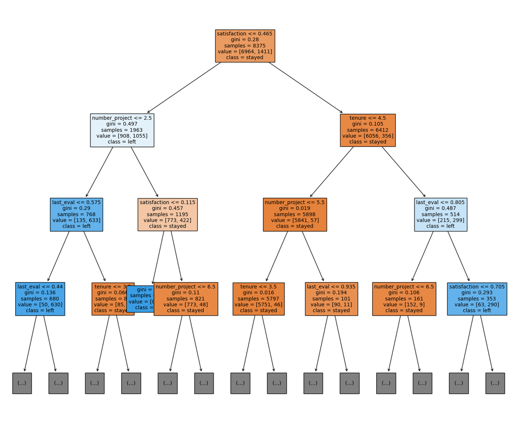

```python
plt.figure(figsize=(18,15))
plot_tree(model_dt2_best_model,max_depth=3, fontsize=10, feature_names=X_test2.columns, class_names={0:'stayed',1:'left'}, filled=True);
plt.show()
```

#### Confusion Matrix Plots

```python
# Prepare confusion matrices for dt1 test
cm_test = metrics.confusion_matrix(y_test2, y_pred_test2)  # Use the optimized model
cm_test_percent = cm_test / cm_test.sum() * 100

# Prepare confusion matrices for dt1 train
cm_train = metrics.confusion_matrix(y_train2, y_pred_train2)  # Use the optimized model
cm_train_percent = cm_train / cm_train.sum() * 100
```

```
<function matplotlib.pyplot.show(close=None, block=None)>
```

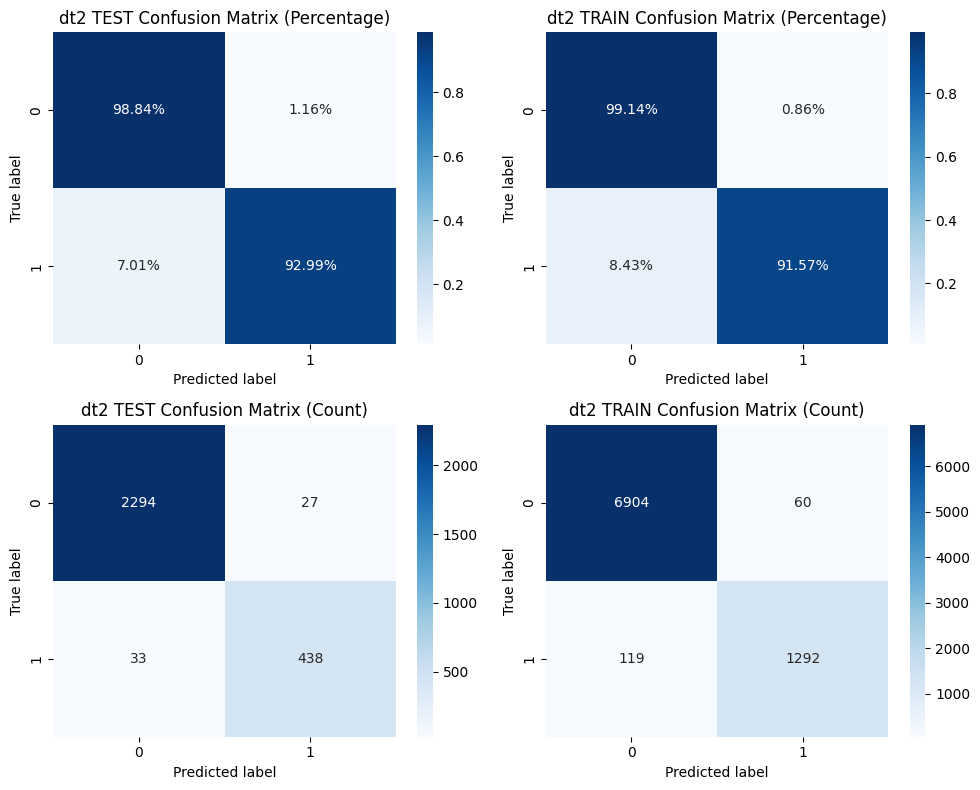

```python
fig, ax = plt.subplots(2, 2, figsize=(10,8))


ax[0,0].set_title("test")

sum_by_true_class = np.sum(cm_test, axis=1)
percentage_matrix = cm_test / sum_by_true_class[:, np.newaxis]

# Create a figure and plot the percentage confusion matrix as a heatmap

sns.heatmap(percentage_matrix, annot=True, fmt=".2%", cmap="Blues", ax = ax[0,0])#, xticklabels=class_labels, yticklabels=class_labels)
ax[0,0].set_title(model_prefix+' TEST Confusion Matrix (Percentage)')
ax[0,0].set_ylabel('True label')
ax[0,0].set_xlabel('Predicted label')


# Create a figure and plot the percentage confusion matrix as a heatmap
sns.heatmap(cm_test, annot=True, fmt=".0f", cmap="Blues", ax = ax[1,0])#, xticklabels=class_labels, yticklabels=class_labels)
ax[1,0].set_title(model_prefix+' TEST Confusion Matrix (Count)')
ax[1,0].set_ylabel('True label')
ax[1,0].set_xlabel('Predicted label')

sum_by_true_class = np.sum(cm_train, axis=1)
percentage_matrix = cm_train / sum_by_true_class[:, np.newaxis]

sns.heatmap(percentage_matrix, annot=True, fmt=".2%", cmap="Blues", ax = ax[0,1])#, xticklabels=class_labels, yticklabels=class_labels)
ax[0,1].set_title(model_prefix+' TRAIN Confusion Matrix (Percentage)')
ax[0,1].set_ylabel('True label')
ax[0,1].set_xlabel('Predicted label')


sns.heatmap(cm_train, annot=True, fmt=".0f", cmap="Blues", ax = ax[1,1])#, xticklabels=class_labels, yticklabels=class_labels)
ax[1,1].set_title(model_prefix+' TRAIN Confusion Matrix (Count)')
ax[1,1].set_ylabel('True label')
ax[1,1].set_xlabel('Predicted label')

plt.tight_layout()
plt.show
```

#### Feature Importance

```python
#tree2_importances = pd.DataFrame(tree2.best_estimator_.feature_importances_, columns=X.columns)
tree_importances = pd.DataFrame(model_dt2.best_estimator_.feature_importances_,
                                 columns=['gini_importance'],
                                 index=X2.columns
                                )
tree_importances = tree_importances.sort_values(by='gini_importance', ascending=False)

# Only extract the features with importances > 0
#tree_importances = tree_importances[tree_importances['gini_importance'] != 0]
tree_importances
```

|  | gini_importance |
| --- | --- |
| satisfaction | 0.5898 |
| tenure | 0.1542 |
| last_eval | 0.1475 |
| number_project | 0.1086 |
| overworked | 0.0000 |
| promotion | 0.0000 |
| salary | 0.0000 |

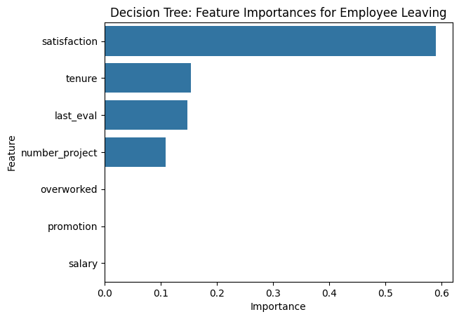

```python
sns.barplot(data=tree_importances, x="gini_importance", y=tree_importances.index, orient='h')
plt.title("Decision Tree: Feature Importances for Employee Leaving", fontsize=12)
plt.ylabel("Feature")
plt.xlabel("Importance")
#plt.gca().invert_yaxis()
plt.show()
```

# Review Results

## Dataset comparison - Decision Tree

There is little difference in performance between the two datasets.

- `ALLFeat` = complete feature engineered dataset
- `NoDept` = dataset with dummy encoded dept removed

## Model performance

```python
display_results()
```

|  | Model | Precision | Recall | F1 | Accuracy | AUC | Predict Leave | Predict Stay |
| --- | --- | --- | --- | --- | --- | --- | --- | --- |
| 5 | dt1 - ALLFeat - test | 0.9780 | 0.9790 | 0.9780 | 0.9790 | 0.9790 | 0.9360 | 0.9870 |
| 6 | dt1 - ALLFeat - train | 0.9780 | 0.9790 | 0.9780 | 0.9790 | 0.9790 | 0.9350 | 0.9870 |
| 8 | dt2 - NOdept - test | 0.9780 | 0.9790 | 0.9780 | 0.9790 | 0.9790 | 0.9360 | 0.9870 |
| 9 | dt2 - NOdept - train | 0.9780 | 0.9790 | 0.9780 | 0.9790 | 0.9790 | 0.9350 | 0.9870 |
| 4 | dt1 - ALLFeat - GS train | 0.9510 | 0.9140 | 0.9320 | 0.9770 | 0.9740 | NaN | NaN |
| 7 | dt2 - NOdept - GS train | 0.9510 | 0.9140 | 0.9320 | 0.9770 | 0.9740 | NaN | NaN |
| 1 | lr1 - ALLFeat - train | 0.7740 | 0.8130 | 0.7860 | 0.8130 | 0.8870 | 0.2580 | 0.8930 |
| 3 | lr2 - NOdept - train | 0.7700 | 0.8110 | 0.7830 | 0.8110 | 0.8860 | 0.2470 | 0.8920 |
| 0 | lr1 - ALLFeat - test | 0.7760 | 0.8110 | 0.7880 | 0.8110 | 0.8780 | 0.2770 | 0.8910 |
| 2 | lr2 - NOdept - test | 0.7670 | 0.8060 | 0.7810 | 0.8060 | 0.8780 | 0.2480 | 0.8890 |

The AUC score for the DecisionTree is [0.978] This is a significant improvement over Logistical Regression which came in at ~0.886 but had a low predicted to leave score.

F1, Precision, Recall and Accuracy are also within acceptable ranges

Predictions have also improved significantly, with predicted to leave now at ~0.9x.

# Feature Importance

The DecisionTree models ranks feature importance as :

[output not shown]

## Conclusion, model comparison - Decision Tree.

Again, there is almost no difference to the performance of the two datasets (`AllFeat`/`NoDept`) when modelled through either Logistic Regression or Decision Tree. While there's a tiny improvement in DecisionTree, there's no difference in feature importance.

The improvement we see in DecisionTree is in predictions, where **predicted to leave** has increased from ~30% to ~94%